# Data explorations for Rochester symposium

2020-03-03 08:09:26

# Purpose

This document describes explorations by Rick Gilmore and Yiming Qian about measures of variability in task performance in the motion duration threshold task.

# Load & clean data

## Motion data

Let’s pick one participant who is highly variable: 20191118083974.

```r
s1 <- readr::read_csv("~/Box Sync/Project_Sex_difference_on_Motion_Perception/data/passed_qa/20191118083974_motion_temporal_threshold.csv")
```

And a second who is very consistent: 2019112209583295

```r
s2 <- readr::read_csv("~/Box Sync/Project_Sex_difference_on_Motion_Perception/data/passed_qa/2019112209583295_motion_temporal_threshold.csv")
```

### Clean the data

```r
clean_motion_df <- function(df) {
  require(tidyverse)
  if (!is.data.frame(df)) stop("Not a valid data frame.")

  df_clean <- df %>%
    dplyr::mutate(., run = run_n + 1) %>%
    dplyr::rename(., corr = correct,
                  dur_s = FWHM)

  df_clean <- df_clean %>%
    dplyr::select(.,
                  run,
                  trial_n,
                  dur_s,
                  corr,
                  rt) %>%
    dplyr::mutate(., run = ordered(run))
  df_clean
}
```

```r
s1 <- clean_motion_df(s1)
s2 <- clean_motion_df(s2)
```

# Visualize

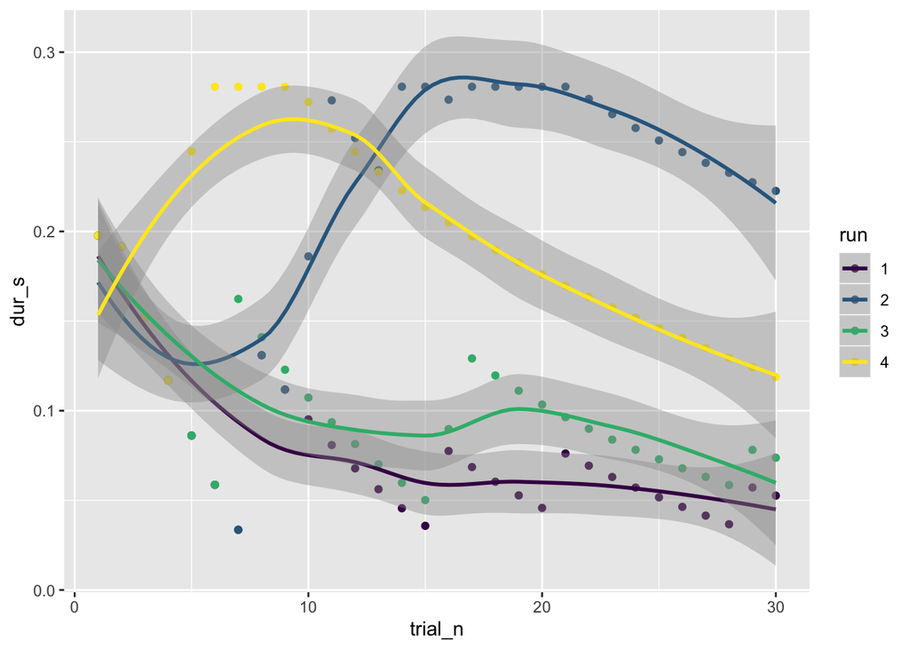

```r
s1 %>% ggplot(.) +
  aes(x = trial_n, y = dur_s, color = run) +
  geom_point() +
  geom_smooth()
```

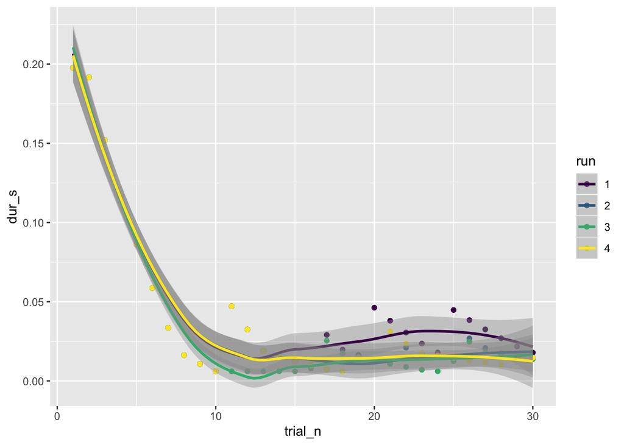

```r
s2 %>% ggplot(.) +
  aes(x = trial_n, y = dur_s, color = run) +
  geom_point() +
  geom_smooth()
```

# Quantify variability

## Duration at trial = 30

```r
s1_tr30 <- dplyr::filter(s1, trial_n == 30)
(s1_tr30_sd <- sd(s1_tr30$dur_s))
```

```
## [1] 0.07563509
```

```r
(s1_tr30_rng <- max(s1_tr30$dur_s) - min(s1_tr30$dur_s))
```

```
## [1] 0.1699432
```

```r
s2_tr30 <- dplyr::filter(s2, trial_n == 30)
(s2_tr30_sd <- sd(s2_tr30$dur_s))
```

```
## [1] 0.001775391
```

```r
(s2_tr30_rng <- max(s2_tr30$dur_s) - min(s2_tr30$dur_s))
```

```
## [1] 0.00405249
```

## Cross-correlation across runs

```r
s1_1 <- s1$dur_s[s1$run == 1]
s1_2 <- s1$dur_s[s1$run == 2]
s1_3 <- s1$dur_s[s1$run == 3]
s1_4 <- s1$dur_s[s1$run == 4]
(s1_runs <- cbind(s1_1, s1_2, s1_3, s1_4))
```

```
##             s1_1       s1_2       s1_3      s1_4
##  [1,] 0.19770896 0.19770896 0.19770896 0.1977090
##  [2,] 0.19164185 0.19164185 0.19164185 0.1916418
##  [3,] 0.15201333 0.15201333 0.15201333 0.1520133
##  [4,] 0.11688662 0.11688662 0.11688662 0.1168866
##  [5,] 0.08614261 0.08614261 0.08614261 0.2446913
##  [6,] 0.05867713 0.05867713 0.05867713 0.2807090
##  [7,] 0.03358110 0.03358110 0.16232521 0.2807090
##  [8,] 0.13095279 0.13095279 0.14100214 0.2807090
##  [9,] 0.11178776 0.11178776 0.12285240 0.2807090
## [10,] 0.09519009 0.18610606 0.10732069 0.2722231
## [11,] 0.08083405 0.27310930 0.09361711 0.2573150
## [12,] 0.06783643 0.25209966 0.08140795 0.2444583
## [13,] 0.05621724 0.23414483 0.07012606 0.2330854
## [14,] 0.04560669 0.28070896 0.05976835 0.2228988
```

[output cut: 16 more lines]

```r
cor(s1_runs)
```

```
##            s1_1       s1_2       s1_3       s1_4
## s1_1  1.0000000 -0.3170786  0.7896120  0.1295156
## s1_2 -0.3170786  1.0000000 -0.3469026 -0.4371680
## s1_3  0.7896120 -0.3469026  1.0000000  0.2030890
## s1_4  0.1295156 -0.4371680  0.2030890  1.0000000
```

```r
s2_1 <- s2$dur_s[s2$run == 1]
s2_2 <- s2$dur_s[s2$run == 2]
s2_3 <- s2$dur_s[s2$run == 3]
s2_4 <- s2$dur_s[s2$run == 4]
(s2_runs <- cbind(s2_1, s2_2, s2_3, s2_4))
```

```
##              s2_1        s2_2        s2_3        s2_4
##  [1,] 0.197701445 0.197701445 0.197701445 0.197701445
##  [2,] 0.191634328 0.191634328 0.191634328 0.191634328
##  [3,] 0.152005817 0.152005817 0.152005817 0.152005817
##  [4,] 0.116879102 0.116879102 0.116879102 0.116879102
##  [5,] 0.086135092 0.086135092 0.086135092 0.086135092
##  [6,] 0.058669613 0.058669613 0.058669613 0.058669613
##  [7,] 0.033573583 0.033573583 0.033573583 0.033573583
##  [8,] 0.016304456 0.016304456 0.016304456 0.016304456
##  [9,] 0.010691410 0.010691410 0.010691410 0.010691410
## [10,] 0.006085490 0.006085490 0.006085490 0.006085490
## [11,] 0.047204694 0.047204694 0.006085490 0.047204694
## [12,] 0.032472573 0.032472573 0.006085490 0.032472573
## [13,] 0.018995995 0.018995995 0.006085490 0.018995995
## [14,] 0.015289104 0.015289104 0.006085490 0.015289104
```

[output cut: 16 more lines]

```r
cor(s2_runs)
```

```
##           s2_1      s2_2      s2_3      s2_4
## s2_1 1.0000000 0.9831835 0.9773249 0.9824169
## s2_2 0.9831835 1.0000000 0.9821225 0.9954672
## s2_3 0.9773249 0.9821225 1.0000000 0.9776008
## s2_4 0.9824169 0.9954672 0.9776008 1.0000000
```

# Discussion

These measures seem to capture the differences we see in the plots, so the next step is to write functions that extract the statistics and gather them across the dataset.

# Analysis of variation across datasets

## Motion task

Let’s create a function to compute variability measures for the motion task.

```r
compute_within_p_var <- function(df) {
  tr30 <- dplyr::filter(df, trial_n == 30)
  tr30_sd <- sd(tr30$dur_s)
  tr30_rng <- max(tr30$dur_s) - min(tr30$dur_s)

  r1 <- df$dur_s[df$run == 1]
  r2 <- df$dur_s[df$run == 2]
  r3 <- df$dur_s[df$run == 3]
  r4 <- df$dur_s[df$run == 4]

  these_runs <- cbind(r1, r2, r3, r4)
  cor_vals <- cor(these_runs)
  mean_cor <- mean(sort(c(cor_vals[1,2],
                   cor_vals[1,3],
                   cor_vals[1,4],
                   cor_vals[2,3],
                   cor_vals[2,4],
                   cor_vals[3,4])))
  med_cor <- median(sort(c(cor_vals[1,2],
                    cor_vals[1,3],
                    cor_vals[1,4],
                    cor_vals[2,3],
                    cor_vals[2,4],
                    cor_vals[3,4])))

  tr30_coef_var <- tr30_sd/mean(tr30$dur_s)

  data.frame(task = "motion", tr30_sd = tr30_sd,
             tr30_rng = tr30_rng, tr30_coef_var = tr30_coef_var,
             mn_run_cor = mean_cor, md_run_cor = med_cor)
}
```

Now, let’s compute across all of the relevant datasets.

```r
compute_motion_var_measures <- function(fn) {
  df <- readr::read_csv(fn)
  df <- clean_motion_df(df)
  var_m_df <- compute_within_p_var(df)
  var_m_df$sub_id <- stringr::str_extract(fn, "[0-9]{3,12}")
  var_m_df
}
```

```r
motion_fl <- list.files("~/Box Sync/Project_Sex_difference_on_Motion_Perception/data/passed_qa", pattern = "motion", full.names = TRUE)

motion_var_df <- purrr::map_dfr(motion_fl,
                                compute_motion_var_measures)
```

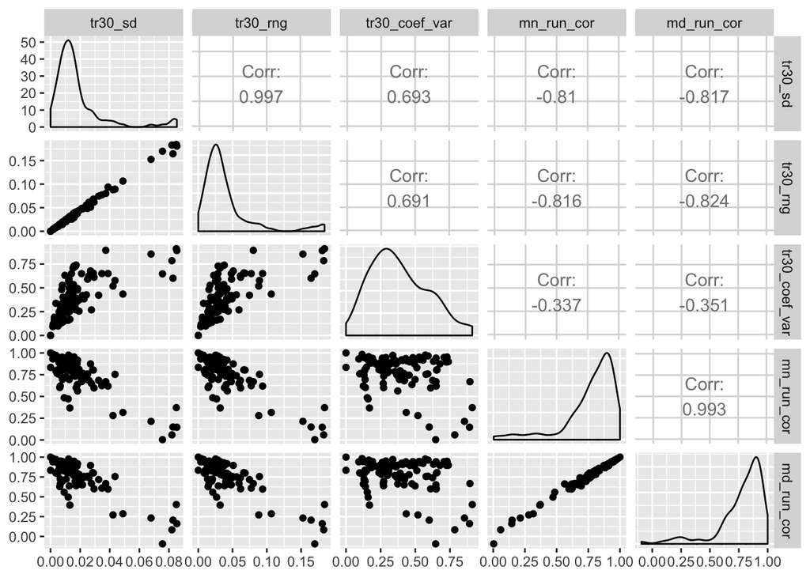

```r
motion_var_df %>%
  dplyr::select(., -sub_id, -task) %>%
  GGally::ggpairs(.)
```

The measures (standard deviation of the trial 30 duration – *tr30_sd*, range of the trial 30 durations – *tr30_rng*, mean of the cross-correlation between pairs of runs – *mn_run_cor*, and the median of the cross-correlation between pairs of runs – *md_run_cor*) show similar patterns, as they should. The measures are not really independent of one another. The main point is that there is variability in these measure of variability!

We now need to do the same for the contrast task data, and then compare the two tasks.

## Contrast task

Let’s do the same thing for the contrast data.

```r
clean_contrast_df <- function(df) {
  require(tidyverse)
  if (!is.data.frame(df)) stop("Not a valid data frame.")

  df_clean <- df %>%
    mutate(., correctAns = stringr::str_extract(correctAns, "left|down|right|up")) %>%
    mutate(., corr = if_else(resp == correctAns, 1, 0)) %>%
    rename(., contr = loop_trial.intensity,
           trial_n = loop_trial.thisN,
           rt = resp.rt) %>%
    mutate(., trial_n = trial_n + 1)

  df_clean <- df_clean %>%
    dplyr::select(., trial_n,
                  contr,
                  corr,
                  rt) %>%
    dplyr::filter(., trial_n >= 0) %>%
    dplyr::mutate(., run = rep(1:4, each=30)) %>%
    dplyr::mutate(., run = ordered(run))

  df_clean
}

compute_within_p_var_contr <- function(df) {
  tr30 <- dplyr::filter(df, trial_n == 30)
  tr30_sd <- sd(tr30$contr)
  tr30_rng <- max(tr30$contr) - min(tr30$contr)

  r1 <- df$contr[df$run == 1]
  r2 <- df$contr[df$run == 2]
  r3 <- df$contr[df$run == 3]
  r4 <- df$contr[df$run == 4]

  these_runs <- cbind(r1, r2, r3, r4)
  cor_vals <- cor(these_runs)
  mean_cor <- mean(sort(c(cor_vals[1,2],
                   cor_vals[1,3],
                   cor_vals[1,4],
                   cor_vals[2,3],
                   cor_vals[2,4],
                   cor_vals[3,4])))
  med_cor <- median(sort(c(cor_vals[1,2],
                    cor_vals[1,3],
                    cor_vals[1,4],
                    cor_vals[2,3],
                    cor_vals[2,4],
                    cor_vals[3,4])))

  tr30_coef_var <- tr30_sd/mean(tr30$contr)
  data.frame(task = "contr", tr30_sd = tr30_sd,
             tr30_rng = tr30_rng, tr30_coef_var = tr30_coef_var,
             mn_run_cor = mean_cor, md_run_cor = med_cor)
}

compute_contr_var_measures <- function(fn) {
  #message(fn)
  df <- readr::read_csv(fn)
  df <- clean_contrast_df(df)
  var_c_df <- compute_within_p_var_contr(df)
  var_c_df$sub_id <- stringr::str_extract(fn, "[0-9]{3,12}")
  var_c_df
}

contrast_fl <- list.files("~/Box Sync/Project_Sex_difference_on_Motion_Perception/data/passed_qa", pattern = "contrast", full.names = TRUE)
```

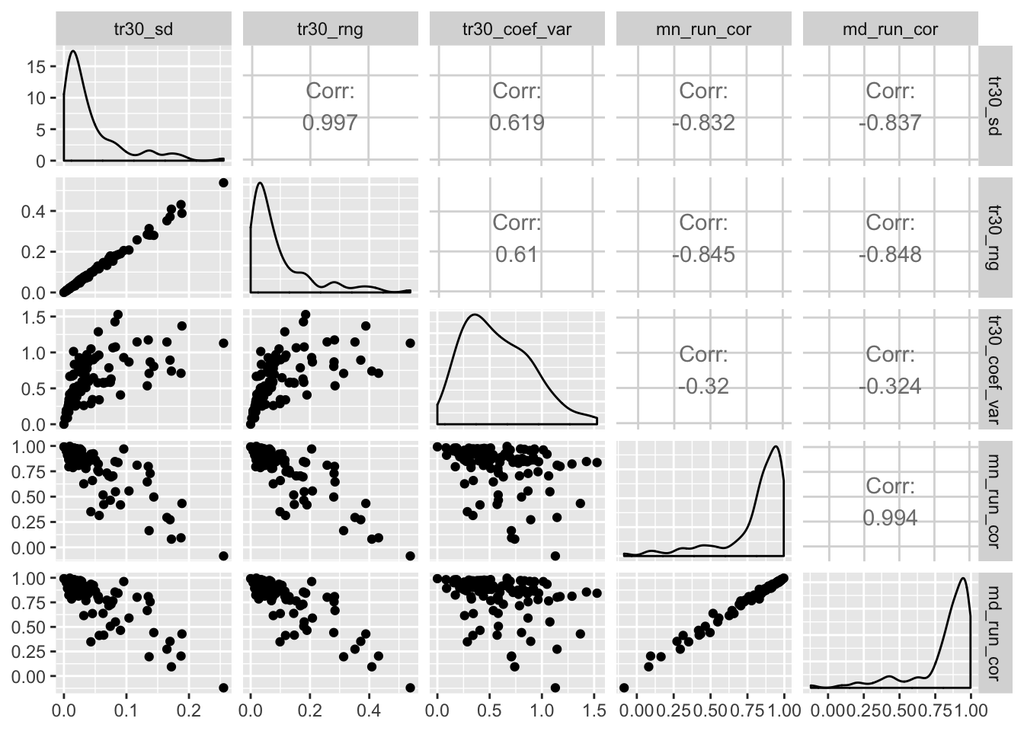

```r
contrast_var_df <- purrr::map_dfr(contrast_fl,
                                  compute_contr_var_measures)
contrast_var_df %>%
  dplyr::select(., -sub_id, -task) %>%
  GGally::ggpairs(.)
```

## Combining the tasks

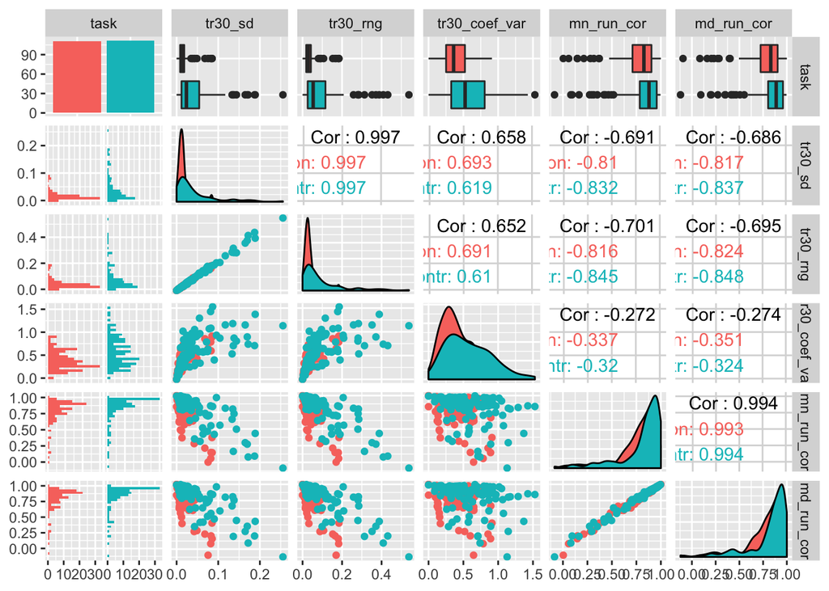

```r
sex_diffs_var_all <- rbind(motion_var_df, contrast_var_df)

sex_diffs_var_all %>%
  dplyr::select(., -sub_id) %>%
  GGally::ggpairs(., aes(color = task))
```